[figure not shown]

# MAPA TEMATICOS PARA PUESTOS DE TRABAJO-ARGENTINA

```python
import geopandas as gpd

linkGit='https://raw.githubusercontent.com/a20242927-alt/TAREA-GRUPAL-1/main/'
linkargentina='gadm41_ARG.gpkg'
```

```python
gpd.list_layers(linkGit+linkargentina)
```

|  | name | geometry_type |
| --- | --- | --- |
| 0 | ADM_ADM_0 | MultiPolygon |
| 1 | ADM_ADM_1 | MultiPolygon |
| 2 | ADM_ADM_2 | MultiPolygon |

Seleccionamos la capa que corresponde a un equivalente a departamentos en Perú

```python
provincias = gpd.read_file(linkGit + linkargentina, layer='ADM_ADM_1')
```

```python
provincias.head()
```

|  | GID_1 | GID_0 | COUNTRY | NAME_1 | VARNAME_1 | NL_NAME_1 | TYPE_1 | ENGTYPE_1 | CC_1 | HASC_1 | ISO_1 | geometry |
| --- | --- | --- | --- | --- | --- | --- | --- | --- | --- | --- | --- | --- |
| 0 | ARG.1_1 | ARG | Argentina | Buenos Aires | Baires\|Buenos Ayres | NA | Provincia | Province | NA | AR.BA | AR-B | MULTIPOLYGON (((-62.10181 -40.55375, -62.10208... |
| 1 | ARG.2_1 | ARG | Argentina | Catamarca | NA | NA | Provincia | Province | NA | AR.CT | AR-K | MULTIPOLYGON (((-65.14583 -28.6656, -65.1441 -... |
| 2 | ARG.3_1 | ARG | Argentina | Chaco | El Chaco\|Presidente Juan Peron | NA | Provincia | Province | NA | AR.CC | AR-H | MULTIPOLYGON (((-60.11628 -25.6566, -60.11488 ... |
| 3 | ARG.4_1 | ARG | Argentina | Chubut | NA | NA | Provincia | Province | NA | AR.CH | AR-U | MULTIPOLYGON (((-66.99986 -45.99986, -66.99986... |
| 4 | ARG.5_1 | ARG | Argentina | Ciudad de Buenos Aires | BUENOS AIRES D.F.\|Capital Federa | NA | Distrito Federal | Federal District | NA | AR.DF | NA | MULTIPOLYGON (((-58.34292 -34.63319, -58.34297... |

Renombramos la columna 'Name_1' a 'provincia'

```python
provincias.rename(columns={'NAME_1': 'provincia'}, inplace=True)
```

```python
import pandas as pd
# 2. Cargar datos de Población
poblacionLink = 'poblacion.csv'
poblacionData = pd.read_csv(linkGit + poblacionLink)
```

```python
## data available
poblacionData.info()
```

```
<class 'pandas.core.frame.DataFrame'>
RangeIndex: 529 entries, 0 to 528
Data columns (total 4 columns):
 #   Column     Non-Null Count  Dtype
---  ------     --------------  -----
 0   id         529 non-null    int64
 1   distrito   529 non-null    object
 2   provincia  529 non-null    object
 3   poblacion  529 non-null    int64
dtypes: int64(2), object(2)
memory usage: 16.7+ KB
```

```python
#3. Cargar el dato para Empleo
empleo = pd.read_csv(linkGit + 'provinciales_serie_empleo_anual_3.csv', header=1)
```

Solo seleccionamos la columna total de empleos para cada provincia

```python
empleo = empleo[['Provincia', 'Total']].dropna(subset=['Total'])
empleo = empleo[empleo['Provincia'] != 'Total']
```

Renombramos Total a la variable empleo

```python
empleo = empleo.rename(columns={'Total': 'empleo'})
```

```python
empleo.head()
```

|  | Provincia | empleo |
| --- | --- | --- |
| 0 | Partidos de GBA | 1201966.0 |
| 1 | Capital Federal | 1610540.0 |
| 2 | Resto de Buenos Aires | 906965.0 |
| 3 | Catamarca | 37344.0 |
| 4 | Córdoba | 550696.0 |

```python
empleo.info()
```

```
<class 'pandas.core.frame.DataFrame'>
Index: 25 entries, 0 to 24
Data columns (total 2 columns):
 #   Column     Non-Null Count  Dtype
---  ------     --------------  -----
 0   Provincia  25 non-null     object
 1   empleo     25 non-null     float64
dtypes: float64(1), object(1)
memory usage: 600.0+ bytes
```

### Geo Merging

1. Para añadir la población por cada provincia

```python
#Encabezado para el dataframe de población
poblacionData.provincia.head()
```

|  | provincia |
| --- | --- |
| 0 | Buenos Aires |
| 1 | Córdoba |
| 2 | Santa Fe |
| 3 | Buenos Aires |
| 4 | Buenos Aires |

**dtype:** object

```python
# encabezado del dataframe de empleo
empleo.Provincia.head()
```

|  | Provincia |
| --- | --- |
| 0 | Partidos de GBA |
| 1 | Capital Federal |
| 2 | Resto de Buenos Aires |
| 3 | Catamarca |
| 4 | Córdoba |

**dtype:** object

```python
provincias['provincia'].head()
```

|  | provincia |
| --- | --- |
| 0 | Buenos Aires |
| 1 | Catamarca |
| 2 | Chaco |
| 3 | Chubut |
| 4 | Ciudad de Buenos Aires |

**dtype:** object

# Fuzzy Merging

```python
!pip install thefuzz
```

```python
from thefuzz.process import extractOne as best
#Identificamos los elementos que no se encuentran en el GDF
onlyDF = set(poblacionData.provincia) - set(provincias.provincia)
onlyGDF = set(provincias.provincia) - set(poblacionData.provincia)
```

```python
onlyDF
```

```
{'Ciudad Autónoma de Buenos Aires',
 'Tierra del Fuego, Antártida e Islas del Atlántico Sur'}
```

```python
onlyGDF
```

```
{'Ciudad de Buenos Aires', 'Tierra del Fuego'}
```

```python
# puntaje de similitud para cada nombre sin pareja
pd.DataFrame([(c, best(c, onlyGDF)[0], best(c, onlyGDF)[1]) for c in onlyDF]).sort_values(2)
```

|  | 0 | 1 | 2 |
| --- | --- | --- | --- |
| 0 | Tierra del Fuego, Antártida e Islas del Atlánt... | Tierra del Fuego | 90 |
| 1 | Ciudad Autónoma de Buenos Aires | Ciudad de Buenos Aires | 95 |

Creamos un diccionario de reemplazos

```python
changesToDF = {c: best(c, onlyGDF)[0] for c in onlyDF}
```

Aplicamos las correcciones a la columna 'provincia' de poblacionData

```python
poblacionData.replace(to_replace={'provincia': changesToDF}, inplace=True)
```

Verificamos que no quedan nombres sin emparejar

```python
print(len(set(poblacionData.provincia) - set(provincias.provincia)),
      len(set(provincias.provincia) - set(poblacionData.provincia)))
```

```
0 0
```

Sumar la población para la misma provincia

```python
poblacionProv = poblacionData.groupby('provincia', as_index=False)['poblacion'].sum()
poblacionProv.shape
```

```
(24, 2)
```

Unimos los datos de provincia y población

```python
mapaProv = provincias.merge(poblacionProv, left_on='provincia', right_on='provincia', how='left')

print(type(mapaProv))
print(len(mapaProv))
print(mapaProv['poblacion'].isna().sum())
print(mapaProv['poblacion'].sum())
```

```
<class 'geopandas.geodataframe.GeoDataFrame'>
24
0
45892285
```

```python
mapaProv.head()
```

|  | GID_1 | GID_0 | COUNTRY | provincia | VARNAME_1 | NL_NAME_1 | TYPE_1 | ENGTYPE_1 | CC_1 | HASC_1 | ISO_1 | geometry | poblacion |
| --- | --- | --- | --- | --- | --- | --- | --- | --- | --- | --- | --- | --- | --- |
| 0 | ARG.1_1 | ARG | Argentina | Buenos Aires | Baires\|Buenos Ayres | NA | Provincia | Province | NA | AR.BA | AR-B | MULTIPOLYGON (((-62.10181 -40.55375, -62.10208... | 17523996 |
| 1 | ARG.2_1 | ARG | Argentina | Catamarca | NA | NA | Provincia | Province | NA | AR.CT | AR-K | MULTIPOLYGON (((-65.14583 -28.6656, -65.1441 -... | 429562 |
| 2 | ARG.3_1 | ARG | Argentina | Chaco | El Chaco\|Presidente Juan Peron | NA | Provincia | Province | NA | AR.CC | AR-H | MULTIPOLYGON (((-60.11628 -25.6566, -60.11488 ... | 1129606 |
| 3 | ARG.4_1 | ARG | Argentina | Chubut | NA | NA | Provincia | Province | NA | AR.CH | AR-U | MULTIPOLYGON (((-66.99986 -45.99986, -66.99986... | 592621 |
| 4 | ARG.5_1 | ARG | Argentina | Ciudad de Buenos Aires | BUENOS AIRES D.F.\|Capital Federa | NA | Distrito Federal | Federal District | NA | AR.DF | NA | MULTIPOLYGON (((-58.34292 -34.63319, -58.34297... | 3121707 |

MERGING

Hacemos los cambios para la variable de empleo

VERIFICAMOS EN QUE SISTEMA SE ENCUENTRA EL GDF

```python
print(mapaProv.crs)
```

```
EPSG:4326
```

REPROYECTAMOS

Usamos ESRI:102033 porque es un crs es un EqualArea projection

```python
mapaProv = mapaProv.to_crs('ESRI:102033')
```

Verificamos la reproyección

```python
# revisar el nombre del sistema y sus unidades
print(mapaProv.crs.name)
print(mapaProv.crs.axis_info[0].unit_name)
```

```
South_America_Albers_Equal_Area_Conic
metre
```

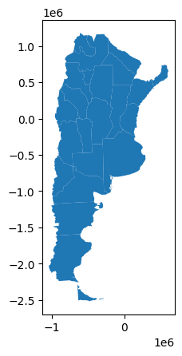

```python
# mapa rápido para ver la forma
mapaProv.plot()
```

```python
empleo.head()
```

|  | Provincia | empleo |
| --- | --- | --- |
| 0 | Partidos de GBA | 1201966.0 |
| 1 | Capital Federal | 1610540.0 |
| 2 | Resto de Buenos Aires | 906965.0 |
| 3 | Catamarca | 37344.0 |
| 4 | Córdoba | 550696.0 |

```python
# Renombramos
empleo = empleo.rename(columns={'Provincia': 'provincia'})
```

```python
onlyDF_emp = set(empleo['provincia']) - set(mapaProv['provincia'])
onlyGDF_emp = set(mapaProv['provincia']) - set(empleo['provincia'])
```

```python
onlyDF_emp
```

```
{'Capital Federal', 'Partidos de GBA', 'Resto de Buenos Aires'}
```

```python
onlyGDF_emp
```

```
{'Buenos Aires', 'Ciudad de Buenos Aires'}
```

Evalúa la similitud del matching automático para identificar qué nombres requieren corrección manual.

```python
pd.DataFrame([(country, best(country,onlyGDF_emp)[0],best(country,onlyGDF_emp)[1]) for country in onlyDF_emp]).sort_values(2)
```

|  | 0 | 1 | 2 |
| --- | --- | --- | --- |
| 0 | Capital Federal | Ciudad de Buenos Aires | 38 |
| 1 | Partidos de GBA | Ciudad de Buenos Aires | 43 |
| 2 | Resto de Buenos Aires | Buenos Aires | 90 |

Hacemos cambios manuales

```python
manualChanges = {
    'Partidos de GBA': 'Buenos Aires',
    'Resto de Buenos Aires': 'Buenos Aires',
}
empleo.replace(to_replace={'provincia': manualChanges}, inplace=True)

# sumar las filas que ahora comparten el mismo nombre (Buenos Aires)
empleo = empleo.groupby('provincia', as_index=False)['empleo'].sum()
```

```python
changesToDF = {prov: best(prov, onlyGDF)[0] for prov in onlyDF}
changesToDF
```

```
{'Tierra del Fuego, Antártida e Islas del Atlántico Sur': 'Tierra del Fuego',
 'Ciudad Autónoma de Buenos Aires': 'Ciudad de Buenos Aires'}
```

```python
print(set(empleo['provincia']) - set(mapaProv['provincia']))
print(set(mapaProv['provincia']) - set(empleo['provincia']))
```

```
{'Capital Federal'}
{'Ciudad de Buenos Aires'}
```

```python
mapaProv = mapaProv.merge(empleo, on='provincia', how='left')
```

```python
mapaProv.info()
```

```
<class 'geopandas.geodataframe.GeoDataFrame'>
RangeIndex: 24 entries, 0 to 23
Data columns (total 14 columns):
 #   Column     Non-Null Count  Dtype
---  ------     --------------  -----
 0   GID_1      24 non-null     object
 1   GID_0      24 non-null     object
 2   COUNTRY    24 non-null     object
 3   provincia  24 non-null     object
 4   VARNAME_1  24 non-null     object
 5   NL_NAME_1  24 non-null     object
 6   TYPE_1     24 non-null     object
 7   ENGTYPE_1  24 non-null     object
 8   CC_1       24 non-null     object
 9   HASC_1     24 non-null     object
 10  ISO_1      24 non-null     object
 11  geometry   24 non-null     geometry
 12  poblacion  24 non-null     int64
 13  empleo     23 non-null     float64
dtypes: float64(1), geometry(1), int64(1), object(11)
memory usage: 2.8+ KB
```

### Preprocessing: distributing dots

Creamos una copia para mostrar los puntos, definimos un tamaño de 10000 empleos representados por cada punto

```python
justDots = mapaProv.copy()
dot_value = 10000
justDots['num_dots'] = (justDots['empleo'] / dot_value).round().fillna(0).astype(int)
print(justDots['num_dots'].sum())   # total de puntos (apunta a 500-2000)
```

```
503
```

```python
#Genera puntos aleatorios dentro de cada polígono según 'num_dots' y desagrega las colecciones (MultiPoint) en filas de puntos individuales
empleos_dots = justDots.sample_points(size=justDots['num_dots']).explode(index_parts=True)
```

```python
empleos_dots = justDots.sample_points(size=justDots['num_dots']).explode(index_parts=True)
```

```python
empleos_dots
```

|  |  | sampled_points |
| --- | --- | --- |
| 0 | 0 | POINT (-255011.168 -653570.724) |
|  | 1 | POINT (219771.247 -651126.817) |
|  | 2 | POINT (86689.731 -475917.904) |
|  | 3 | POINT (109118.225 -327832.316) |
|  | 4 | POINT (164359.889 -344020.355) |
| ... | ... | ... |
| 23 | 12 | POINT (-518889.339 527079.034) |
|  | 13 | POINT (-493440.368 490727.952) |
|  | 14 | POINT (-467606.896 648911.903) |
|  | 15 | POINT (-504837.095 577567.212) |
|  | 16 | POINT (-559506.139 517777.323) |

503 rows × 1 columns

**dtype:** geometry

```python
#Comprobamos que es una geoserie
type(empleos_dots)
```

```
geopandas.geoseries.GeoSeries
def __init__(data=None, index=None, crs: Any | None=None, **kwargs)
```

[output not shown]

[output cut: 17 more lines]

[output not shown]

*Convertimos la geoserie en un Geodatframe*

```python
dotsGDF = gpd.GeoDataFrame(geometry=empleos_dots.reset_index(drop=True))
```

Verificamos el encabezado

```python
dotsGDF.head()
```

|  | geometry |
| --- | --- |
| 0 | POINT (-255011.168 -653570.724) |
| 1 | POINT (219771.247 -651126.817) |
| 2 | POINT (86689.731 -475917.904) |
| 3 | POINT (109118.225 -327832.316) |
| 4 | POINT (164359.889 -344020.355) |

# Graficamos

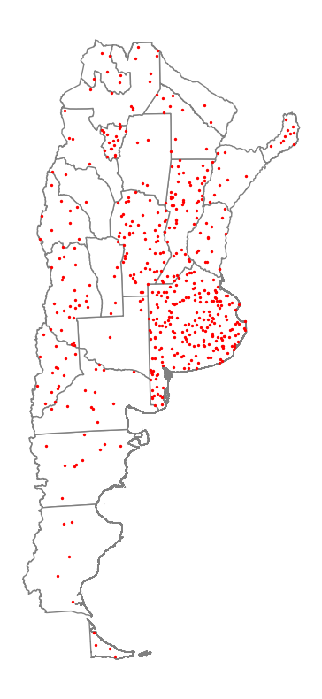

```python
base = mapaProv.plot(facecolor="white", edgecolor="grey", figsize=(8, 10))
dotsGDF.plot(markersize=2, color="red", ax=base)
base.set_axis_off()
```

```python
print(mapaProv.crs)
```

```
ESRI:102033
```

# Mapa tematico de simbolos proporcionales

```python
#verificamos las columnas
print(mapaProv.columns.tolist())
```

```
['GID_1', 'GID_0', 'COUNTRY', 'provincia', 'VARNAME_1', 'NL_NAME_1', 'TYPE_1', 'ENGTYPE_1', 'CC_1', 'HASC_1', 'ISO_1', 'geometry', 'poblacion', 'empleo']
```

```python
mapaProv = mapaProv.to_crs('ESRI:102033')
```

### GDF de centroides

1. Asignamos una localidad para cada centroide, usando los representative points

```python
# 1. Recrear los centroides (representative_point) con el mapaProv ya limpio
mapaProv_centroids = mapaProv.copy()
mapaProv_centroids['geometry'] = mapaProv.representative_point()
```

```python
# 2. Tamaño según empleo
mapaProv_centroids['size'] = mapaProv_centroids['empleo'].apply(lambda x: x**0.5 / 3)
```

Ahora trabajamos en el mapa base

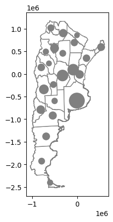

```python
base = mapaProv.plot(facecolor="white", edgecolor='grey')

# pongo los centroides encima del mapa base
mapaProv_centroids.plot(
    ax=base,
    markersize=mapaProv_centroids['size'],
    color='grey'
)
```

Hacemos el boxplot para encontrar las provincias con "empleos" atípicos

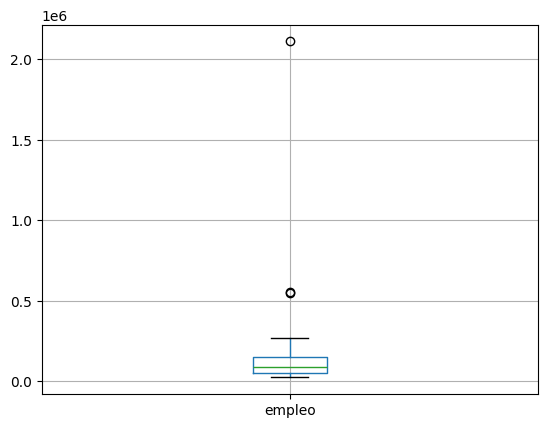

```python
# 3. Boxplot con los datos ya corregidos
boxplotInfo = mapaProv_centroids.boxplot(column='empleo', return_type="dict")
```

Resaltamos los ouliers

```python
# 3. Outliers
outliers = boxplotInfo['fliers'][0].get_ydata()
outliers
```

```
array([2108931.0, 550696.0, 547078.0], dtype=object)
```

Aquí las provincias con valores de empleo por encima del límite superior

```python
mapaProv_centroids[mapaProv_centroids.empleo.isin(outliers)]
```

|  | GID_1 | GID_0 | COUNTRY | provincia | VARNAME_1 | NL_NAME_1 | TYPE_1 | ENGTYPE_1 | CC_1 | HASC_1 | ISO_1 | geometry | poblacion | empleo | size |
| --- | --- | --- | --- | --- | --- | --- | --- | --- | --- | --- | --- | --- | --- | --- | --- |
| 0 | ARG.1_1 | ARG | Argentina | Buenos Aires | Baires\|Buenos Ayres | NA | Provincia | Province | NA | AR.BA | AR-B | POINT (-9892.25 -589748.004) | 17523996 | 2108931.0 | 484.071964 |
| 5 | ARG.6_1 | ARG | Argentina | Córdoba | Cordova | NA | Provincia | Province | NA | AR.CB | NA | POINT (-327023.057 -34620.663) | 3840905 | 550696.0 | 247.362981 |
| 20 | ARG.21_1 | ARG | Argentina | Santa Fe | Santa Fé | NA | Provincia | Province | NA | AR.SF | AR-S | POINT (-90504 93718.359) | 3544908 | 547078.0 | 246.549071 |

Creamos una columna tipo bandera

```python
mapaProv_centroids['empleo_outlier'] = mapaProv_centroids.empleo.isin(outliers) * 1
```

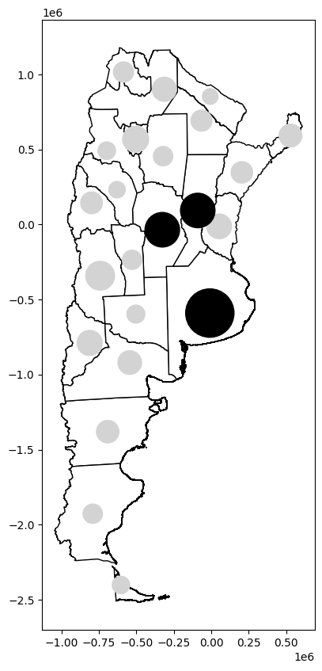

```python
base = mapaProv.plot(color='white', edgecolor='black', figsize=(10, 10))

# defino el color para outlier vs no outlier
mapcolor = {1: 'black', 0: 'lightgrey'}

mapaProv_centroids.plot(
    ax=base,
    markersize=mapaProv_centroids['size'] * 4,
    color=mapaProv_centroids['empleo_outlier'].map(mapcolor)
)
```

1. Creamos dos mapas de centroides y modificamos su tamaño

```python
# separar en dos capas
mapaProv_centroids_out = mapaProv_centroids[mapaProv_centroids.empleo_outlier == 1].copy()
mapaProv_centroids_no_out = mapaProv_centroids[mapaProv_centroids.empleo_outlier == 0].copy()
```

```python
# recalcular tamaños en cada capa
mapaProv_centroids_out['size'] = mapaProv_centroids_out['empleo'].apply(lambda x: x**0.5 / 3)
mapaProv_centroids_no_out['size'] = mapaProv_centroids_no_out['empleo'].apply(lambda x: x**0.5 / 3)
```

Ahora graficamos nuestro mapa y usamos gradiente de colores para los paises que no son ouliers:

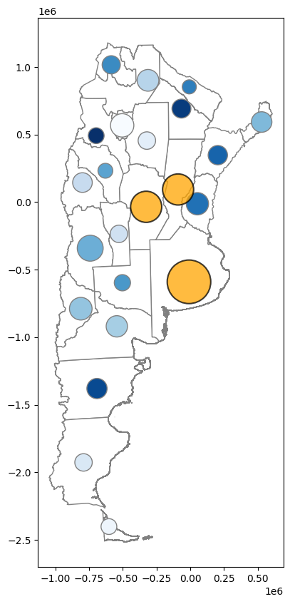

```python
base = mapaProv.plot(color='white', edgecolor='grey', figsize=(10, 10))

# gradiente de color para los no outliers, según su tamaño
mapaProv_centroids_no_out.plot(
    ax=base,
    markersize=mapaProv_centroids_no_out['size'] * 4,
    edgecolor='grey',
    c=mapaProv_centroids_no_out['size'],
    cmap='Blues_r'
)

# outliers destacados en naranja, con borde y transparencia para distinguir la superposición
mapaProv_centroids_out.plot(
    ax=base,
    markersize=mapaProv_centroids_out['size'] * 4,
    color='orange',
    edgecolor='black',
    linewidth=1.5,
    alpha=0.75
)
```

# Thematics: Choropleths

Procesamos los datos: Discretización

```python
##! pip show numba mapclassify numpy
```

Discretizaremos los datos (empleo/población):

```python
# Genero la variable normalizada de empleo per cápita
mapaProv['empleo_poblacion'] = mapaProv.empleo / mapaProv.poblacion
```

Exploremos los algoritmos de agrupación:

```python
import mapclassify
import numpy as np

np.random.seed(12345) # Fijamos la semilla para obtener siempre los mismos resultados

# Definimos 5 intervalos para la clasificación
K = 5

# Eliminamos valores nulos de la serie para asegurar el cálculo del ADCM
theVar = mapaProv['empleo_poblacion'].dropna()

# Mismo ancho de intervalo, interpretación sencilla
ei5 = mapclassify.EqualInterval(theVar, k=K)

# Intervalos basados en desviación estándar y media
msd = mapclassify.StdMean(theVar)

# Cuantiles
q5 = mapclassify.Quantiles(theVar, k=K)

# Basado en similitud, ideal para datos multimodales
mb5 = mapclassify.MaximumBreaks(theVar, k=K)

# Basado en similitud, excelente para datos sesgados
ht = mapclassify.HeadTailBreaks(theVar)

# Algoritmos de optimización
fj5 = mapclassify.FisherJenks(theVar, k=K)
jc5 = mapclassify.JenksCaspall(theVar, k=K)
```

Para escoger la mejor clasificación usamos las desviación absoluta y la comparamos con la mediana.

```python
import pandas as pd
import numpy as np

# Agrupo los clasificadores generados (sin incluir mp5)
class5 = ei5, msd, q5, mb5, ht, fj5, jc5

# Recolecto el ADCM de cada clasificador
fits = np.array([c.adcm for c in class5])

# Convierto los puntajes ADCM a un DataFrame
adcms = pd.DataFrame(fits)

# Agrego los nombres de los clasificadores
adcms['classifier'] = [c.name for c in class5]

# Nombro las columnas de la tabla
adcms.columns = ['ADCM', 'Classifier']
```

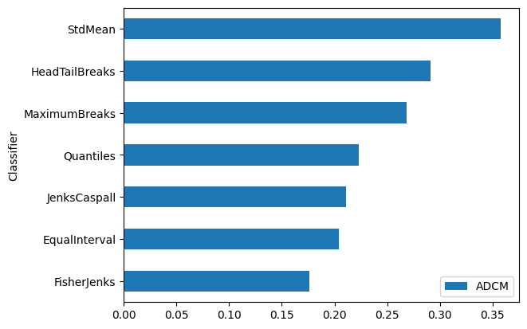

```python
adcms.sort_values('ADCM').plot.barh(x='Classifier')
```

Guardemos la mejor estrategia (menor valor es mayor precisión ) FisherJenks

```python
mapaProv['empleo_poblacion_FJ5'] = pd.Series(fj5.yb, index=theVar.index)
```

```python
# Revisamos los primeros 20 resultados
mapaProv[['empleo_poblacion', 'empleo_poblacion_FJ5']].head(20)
```

|  | empleo_poblacion | empleo_poblacion_FJ5 |
| --- | --- | --- |
| 0 | 0.120345 | 2.0 |
| 1 | 0.086935 | 1.0 |
| 2 | 0.066886 | 1.0 |
| 3 | 0.166324 | 3.0 |
| 4 | NaN | NaN |
| 5 | 0.143377 | 3.0 |
| 6 | 0.067747 | 1.0 |
| 7 | 0.102029 | 2.0 |
| 8 | 0.038013 | 0.0 |
| 9 | 0.079319 | 1.0 |
| 10 | 0.113003 | 2.0 |
| 11 | 0.074096 | 1.0 |
| 12 | 0.129710 | 2.0 |
| 13 | 0.081024 | 1.0 |
| 14 | 0.216214 | 4.0 |
| 15 | 0.161930 | 3.0 |
| 16 | 0.089941 | 1.0 |
| 17 | 0.105467 | 2.0 |
| 18 | 0.098689 | 2.0 |
| 19 | 0.161218 | 3.0 |

```python
# Reagrupamiento y renombrado de etiquetas
newLabelsForLevels = {0: "0_VeryLow", 1: "1_Low", 2: "2_Middle", 3: "3_High", 4: "4_VeryHigh"}

mapaProv['empleo_poblacion_FJ5_cat'] = mapaProv.loc[:, 'empleo_poblacion_FJ5'].replace(newLabelsForLevels)

# Resultado obtenido
mapaProv[['empleo_poblacion', 'empleo_poblacion_FJ5', 'empleo_poblacion_FJ5_cat']].head(20)
```

|  | empleo_poblacion | empleo_poblacion_FJ5 | empleo_poblacion_FJ5_cat |
| --- | --- | --- | --- |
| 0 | 0.120345 | 2.0 | 2_Middle |
| 1 | 0.086935 | 1.0 | 1_Low |
| 2 | 0.066886 | 1.0 | 1_Low |
| 3 | 0.166324 | 3.0 | 3_High |
| 4 | NaN | NaN | NaN |
| 5 | 0.143377 | 3.0 | 3_High |
| 6 | 0.067747 | 1.0 | 1_Low |
| 7 | 0.102029 | 2.0 | 2_Middle |
| 8 | 0.038013 | 0.0 | 0_VeryLow |
| 9 | 0.079319 | 1.0 | 1_Low |
| 10 | 0.113003 | 2.0 | 2_Middle |
| 11 | 0.074096 | 1.0 | 1_Low |
| 12 | 0.129710 | 2.0 | 2_Middle |
| 13 | 0.081024 | 1.0 | 1_Low |
| 14 | 0.216214 | 4.0 | 4_VeryHigh |
| 15 | 0.161930 | 3.0 | 3_High |
| 16 | 0.089941 | 1.0 | 1_Low |
| 17 | 0.105467 | 2.0 | 2_Middle |
| 18 | 0.098689 | 2.0 | 2_Middle |
| 19 | 0.161218 | 3.0 | 3_High |

Ahora podemos hacer el mapa coroplético discreto:

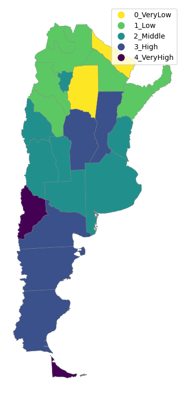

```python
import matplotlib.pyplot as plt

f, ax = plt.subplots(1, figsize=(10, 10))
mapaProv.plot(column='empleo_poblacion_FJ5_cat', # variable a graficar
              cmap='viridis_r', # mapa de colores
              categorical=True, # se interpreta como categoría
              edgecolor='grey', # color del borde
              linewidth=0.3, # ancho del borde
              legend=True, # ¿necesitamos leyenda?
              ax=ax
)

ax.set_axis_off()
```